# Rec

Lucas Meller Dias de Oliveira (14203854)

05 de Dezembro, 2019

# Trabalho de Recuperação

Este trabalho foi realizado para fim da Recuperação de Nota referente ao segundo semestre de 2019.

Esse por objetivo avaliar os conhecimentos referentes a:

- Análise de Dados
- Teste de Hipótese
- Poder do Teste
- ANOVA
- Séries Temporais

## Análise de Dados

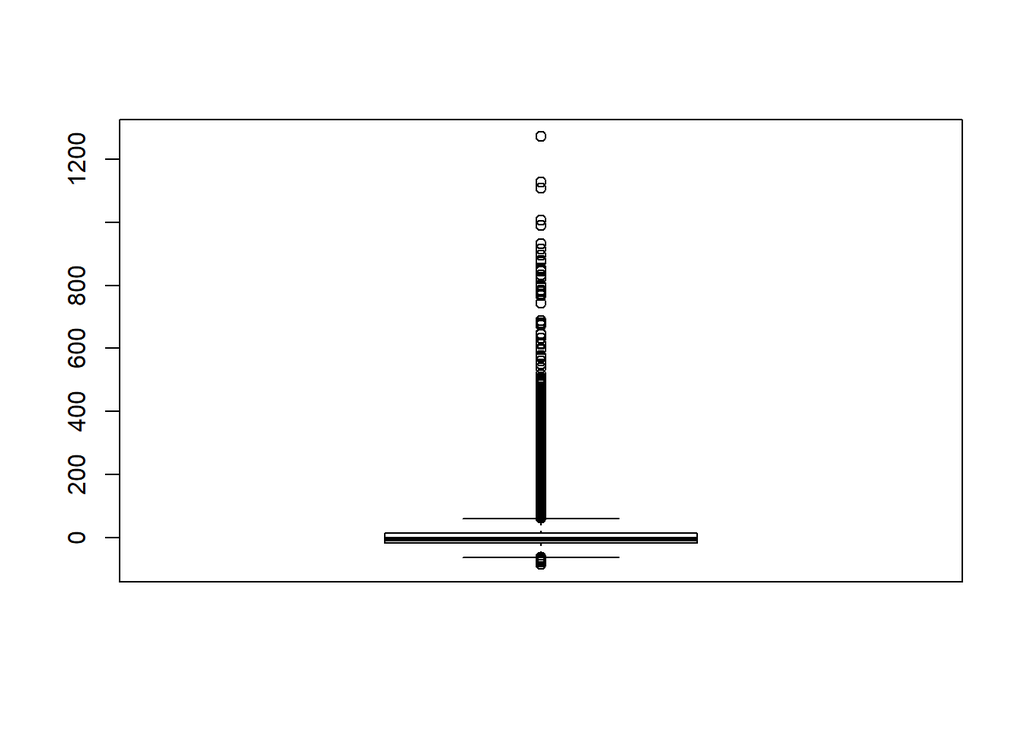

## Teste de Hipótese

O exercício de Teste de Hipótese será avaliar os dados a seguir em relação a:

- Se o exercício foi bem sucedido
- O p-valor do Teste

```
##    Supervisor Antes_do_Treinamento Depois_do_Treinamento Diferenca
## 1           1                   63                    78        15
## 2           2                   93                    92        -1
## 3           3                   84                    91         7
## 4           4                   72                    80         8
## 5           5                   65                    69         4
## 6           6                   72                    85        13
## 7           7                   91                    99         8
## 8           8                   84                    82        -2
## 9           9                   71                    81        10
## 10         10                   80                    87         7
```

Realizando um Teste de Hipótese a partir da distribuição T de Student (n pequeno) com nível de significância 0.1, queremos avaliar as seguintes hipóteses nula e alternativa:

- H0: média antes do treino = média após o treino
- Ha: média antes do treino != média após o treino

Enfim, geramos a partir do teste no Software R o seguinte resultado:

```
##
##  Paired t-test
##
## data:  Depois_do_Treinamento and Antes_do_Treinamento
## t = 4.0219, df = 9, p-value = 0.00301
## alternative hypothesis: true difference in means is not equal to 0
## 90 percent confidence interval:
##   3.755085 10.044915
## sample estimates:
## mean of the differences
##                     6.9
```

Utilizando os resultados de Depois do treinamento como base, o Teste T de hipótese nos leva a crer que para nível de significância 0.1, há dados estatísticos o suficiente para inferir uma melhoria significativa de performance no treinamento dos supervisores (p-valor < 0.5*(nível de significância)).

O p-valor pequeno indica que a Hipótese nula (média antes do treino = média após o treino) foi refutada a partir das considerações iniciais do teste.

## ANOVA

Para o exercício de ANOVA (Ou análise de variância), usaremos uma tabela (descrita abaixo), para detectar diferença entre tratamentos de um teste clínico, utilizando o one-way ANOVA:

```
##   Remedio Placebo Nada
## 1      70      37    3
## 2      77      43   10
## 3      83      50   17
## 4      90      57   23
## 5      97      63   30
```

Utilizaremos o software RStudio para verificar possível relação entre Remédio e Placebo, Remédio e Grupo de Controle (Nada), e entre Placebo e Grupo de Controle.

```
##             Df Sum Sq Mean Sq F value   Pr(>F)
## Placebo      1  448.1   448.1    1203 5.27e-05 ***
## Residuals    3    1.1     0.4
## ---
## Signif. codes:  0 '***' 0.001 '**' 0.01 '*' 0.05 '.' 0.1 ' ' 1
```

```
##             Df Sum Sq Mean Sq F value   Pr(>F)
## Nada         1  448.4   448.4    1682 3.19e-05 ***
## Residuals    3    0.8     0.3
## ---
## Signif. codes:  0 '***' 0.001 '**' 0.01 '*' 0.05 '.' 0.1 ' ' 1
```

```
##             Df Sum Sq Mean Sq F value   Pr(>F)
## Nada         1  434.9   434.9    1203 5.27e-05 ***
## Residuals    3    1.1     0.4
## ---
## Signif. codes:  0 '***' 0.001 '**' 0.01 '*' 0.05 '.' 0.1 ' ' 1
```

Nota-se que para os três testes o p-valor teve valor baixo (ordem de 10^-5 a 10^-4). Portanto, a Hipótese nula, de que as variâncias entre os dados é nula pode ser refutada, visto que há algum outro tipo de relação entre as variáveis (são dependentes) ou a diferença entre as amostras é significativa (sem correlação).

```
##              Df Sum Sq Mean Sq  F value Pr(>F)
## Placebo       1  448.1   448.1 1005.945 0.0201 *
## Nada          1    0.5     0.5    1.034 0.4947
## Placebo:Nada  1    0.2     0.2    0.475 0.6160
## Residuals     1    0.4     0.4
## ---
## Signif. codes:  0 '***' 0.001 '**' 0.01 '*' 0.05 '.' 0.1 ' ' 1
```

## Séries Temporais

Para a matéria de séries temporais, exploraremos os modelos ETS, ARIMA e de Regressão a fim de definir qual o melhor modelo de previsão para o dataset austourists.

Para o dataset original, temos a seguinte configuração e previsão (modelo mais adequado):

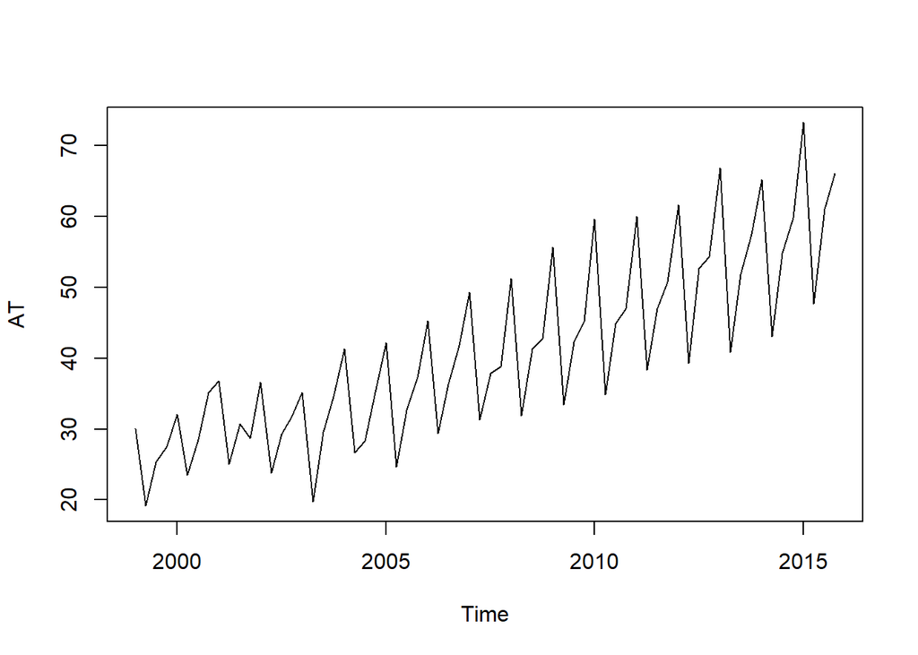

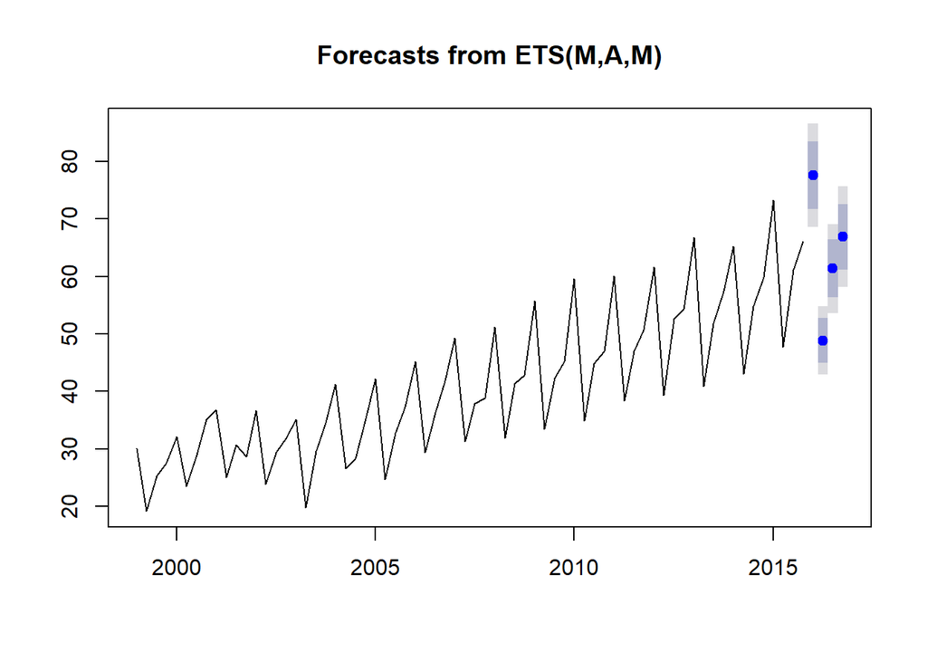

Indicando certa sazonalidade. Os dados ocorrem trimestralmente, portanto para o a previsão (forecast), utilizaremos h=4 (previsão de 4 dados = um ano).

Para o modelo ETS, temos o seguinte modelo e previsão (gráfico):

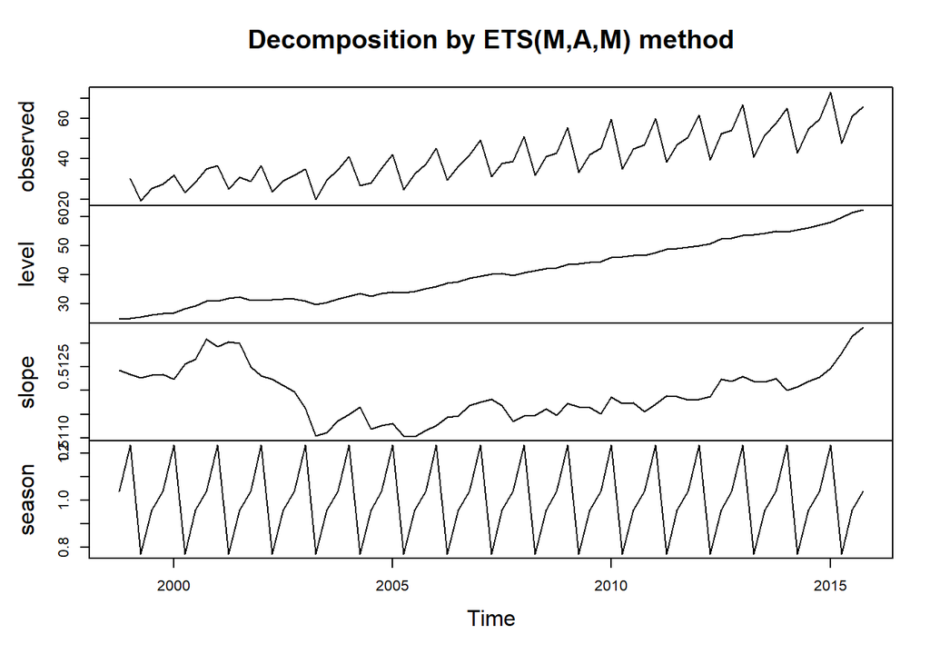

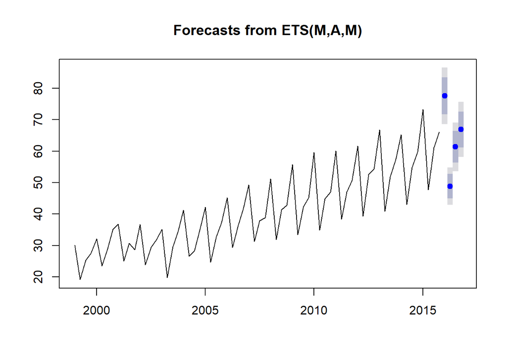

Para o modelo ARIMA, temos o seguinte modelo e previsão (gráfico):

```
## Series: AT
## ARIMA(1,0,0)(1,1,0)[4] with drift
##
## Coefficients:
##          ar1     sar1   drift
##       0.4705  -0.5305  0.5489
## s.e.  0.1154   0.1122  0.0864
##
## sigma^2 estimated as 5.15:  log likelihood=-142.48
## AIC=292.97   AICc=293.65   BIC=301.6
##
## Training set error measures:
##                      ME     RMSE      MAE        MPE     MAPE      MASE
## Training set 0.02200144 2.149384 1.620917 -0.7072593 4.388288 0.5378929
##                     ACF1
## Training set -0.06393238
```

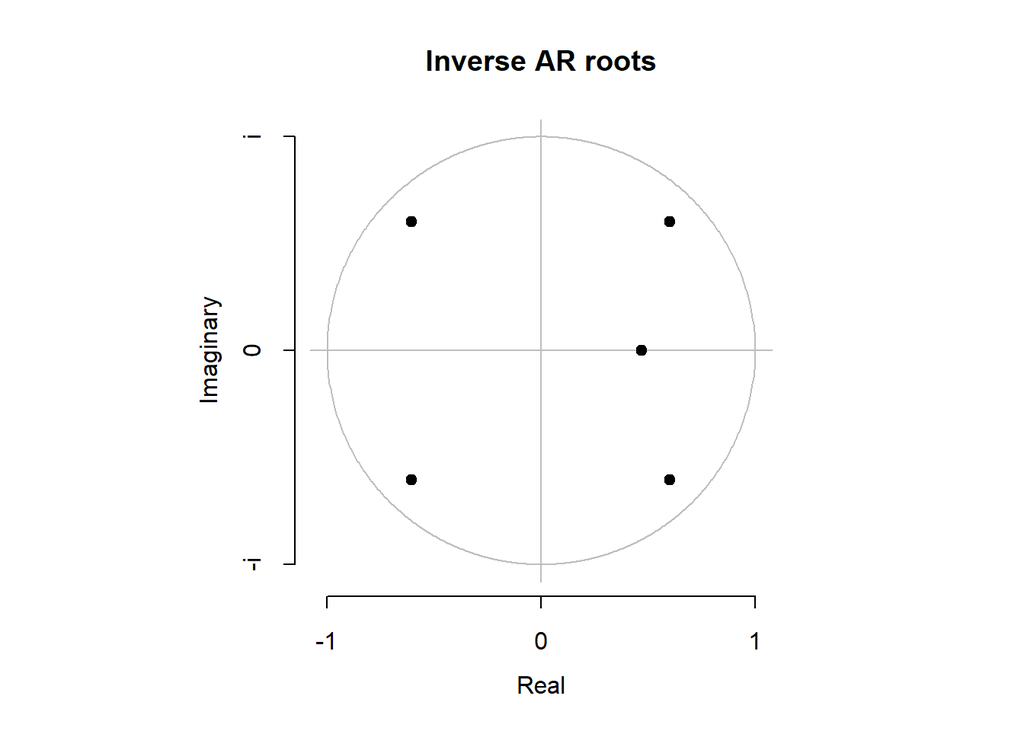

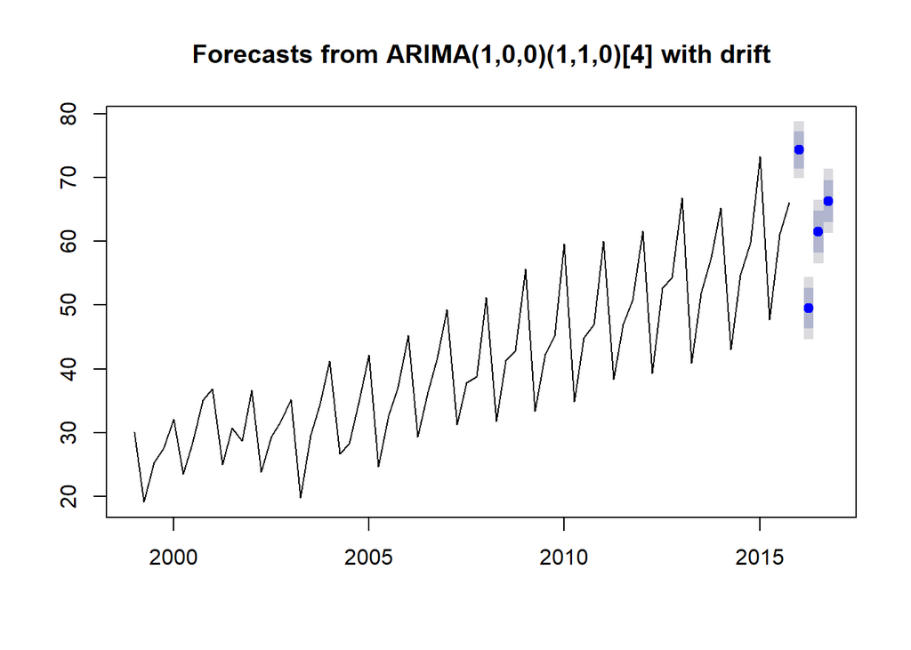

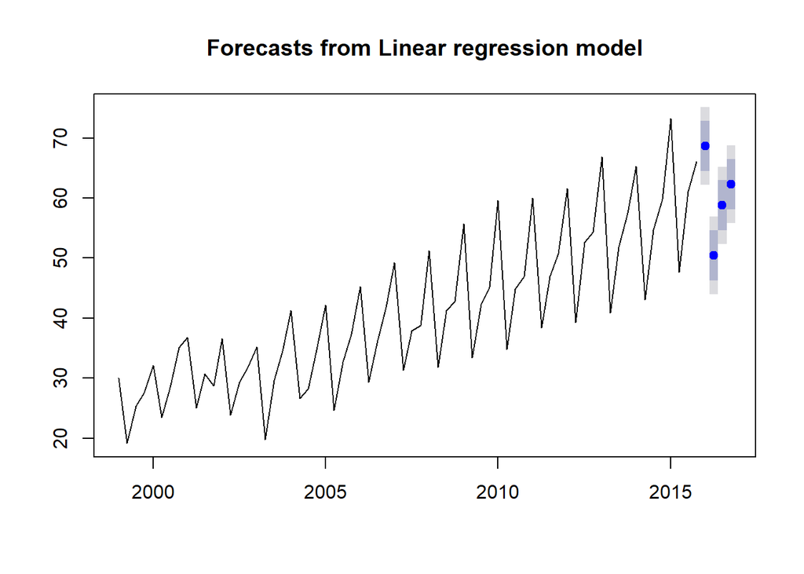